# SBBG Elings Park Analysis

Caroline Shepherd

2024-02-27

```r
# read in packages

library(janitor) #helps clean data, idk if it does anything else
library(tidyverse) #helps clean and manipulate data
library(here) #helps read in data
library(dplyr) #helps with data analysis
library(stargazer) #helps make pretty tables to show data in knitted html or to save as png
library(lubridate) #helps R recognize dates
library(kableExtra) #this was blocked by IT for a bit, but it's working now and I like it for making tables better than stargazer
```

## Introduction:

This code aims to synthesize and visualize data collected on biomass (kg/m2) and mortality of plants in the Elings Park Restoration Project. The Santa Barbara Botanic Garden, in partnership with Channel Islands Restoration, is transforming a 1-acre plot of land previously full of invasive weeds, into a better-functioning native habitat.

In this analysis, we explore the relationship between different weed treatments (sheet mulching and plastic tarping) and plant mortality and growth.

```r
# read in the data
# Make sure you have the most updated data
elings_data <- read.csv(here("ElingsMonitoringData_2024July.csv")) %>%
  clean_names() %>%
  filter(species_id != "EMPTY") %>%
  rename(width1_cm = width1_cm_widest_diameter, # changing column names to be less annoying
         width2_cm = width2_cm_perpendicular_to_w1_measurement) %>%
  mutate(width1_m = width1_cm/100,  #making a width column in meters instead of cm
         width2_m = width2_cm/100,
         height2_m = height_cm) %>%
  mutate(veg_type = case_when(species_id == "BOBA" ~ "herb", # need to be able to sort by plant type for biomass equation
                              species_id == "STPU" ~ "herb",
                              species_id == "BRCA" ~ "herb",
                              species_id == "CAMA" ~ "herb",
                              species_id == "COFI" ~ "herb",
                              species_id == "EPCA" ~ "herb",
                              species_id == "GRCA" ~ "herb",
                              species_id == "LECO" ~ "herb",
                              species_id == "SODO" ~ "herb",
                              species_id == "SPAM" ~ "herb",
                              species_id == "ACGL" ~ "shrub",
                              species_id == "AGSH" ~ "shrub",
                              species_id == "ARCA" ~ "shrub",
                              species_id == "ATLE" ~ "shrub",
                              species_id == "BAPI" ~ "shrub",
                              species_id == "BEEM" ~ "shrub",
                              species_id == "ENCA" ~ "shrub",
                              species_id == "ERFA" ~ "shrub",
                              species_id == "EUMI" ~ "shrub",
                              species_id == "HEWH" ~ "shrub",
                              species_id == "ISME" ~ "shrub",
                              species_id == "LEGI" ~ "shrub",
                              species_id == "LYCA" ~ "shrub",
                              species_id == "MAFA" ~ "shrub",
                              species_id == "PEAR" ~ "shrub",
                              species_id == "RHCR" ~ "shrub",
                              species_id == "RHIN" ~ "shrub",
                              species_id == "SAAP" ~ "shrub")) %>%
  mutate(mort_status = case_when(mortality_status == "A" ~ "1",
                                      mortality_status == "D" ~ "0")) #changing A and D to 1 and 0 for easier coding

# Below, I work with changing characters for dates and other variables to be easier to work with
#checking the class of mortality_status column
class(elings_data$mortality_status)
```

```
## [1] "character"
```

```r
#changing class to numeric
elings_data$mort_status <- as.numeric(elings_data$mort_status)
#checking to see if it worked
class(elings_data$mort_status)
```

```
## [1] "numeric"
```

```r
#using lubridate to work with dates
elings_data$date_lbd <- parse_date_time(elings_data$date, "ymd")
#checking class of date columns
class(elings_data$date_lbd)
```

```
## [1] "POSIXct" "POSIXt"
```

```r
class(elings_data$date)
```

```
## [1] "character"
```

```r
#Filtering to only work with current data (the first data collection was so soon after planting it makes more sense to analyze the more recent data)
elings_data <- elings_data %>%
  filter(date > "2024-05-01")

# need to create function to calculate biomass - jk I made it in excel. Still might want to make it in R at some point

# group by plot and sum biomass
biomass_plot <- elings_data %>%
  group_by(plot_id) %>%
  summarise(biomass_sum = sum(biomass_kg_m2))

# group by plot and sum mortality
# I double checked and this is correctly summing # of alive plants

mort_plot <- elings_data %>%
  group_by(plot_id) %>%
  summarise(mort_sum = sum(mort_status, na.rm = TRUE))

# group by treatment and sum biomass
biomass_treatment <- elings_data %>%
  group_by(treatment) %>%
  summarise(biomass_sum = sum(biomass_kg_m2))

# group by treatment and sum mortality
mort_treatment <- elings_data %>%
  group_by(treatment) %>%
  summarise(mort_sum = sum(mort_status, na.rm = TRUE))
```

### Data exploration

Looking at trends in mortality and biomass based on plot and treatment.

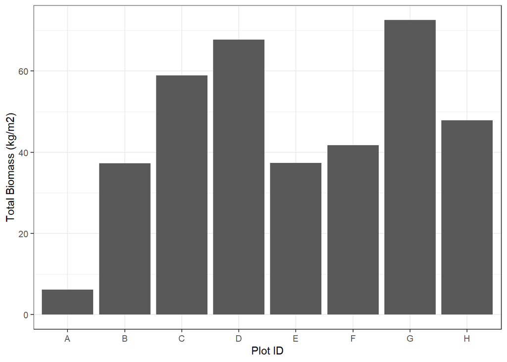

```r
# explore the data! look at trends!

#graphing biomass by plot
ggplot(data = biomass_plot, aes(x = plot_id, y = biomass_sum)) +
  geom_col() +
  theme_bw() +
  labs(x = "Plot ID",
       y = "Total Biomass (kg/m2)")
```

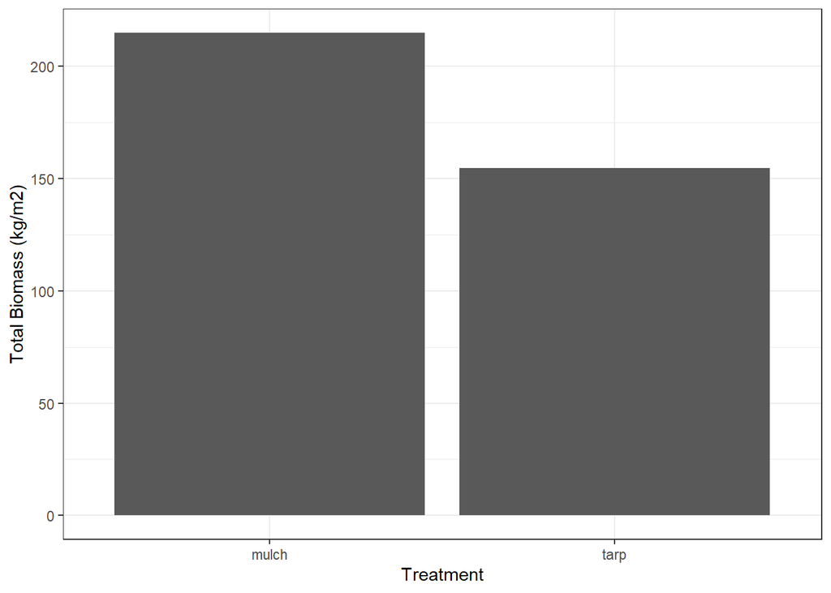

```r
# graphing biomass by treatment
ggplot(data = biomass_treatment, aes(x = treatment, y = biomass_sum)) +
  geom_col() +
  theme_bw() +
  labs(x = "Treatment",
       y = "Total Biomass (kg/m2)")
```

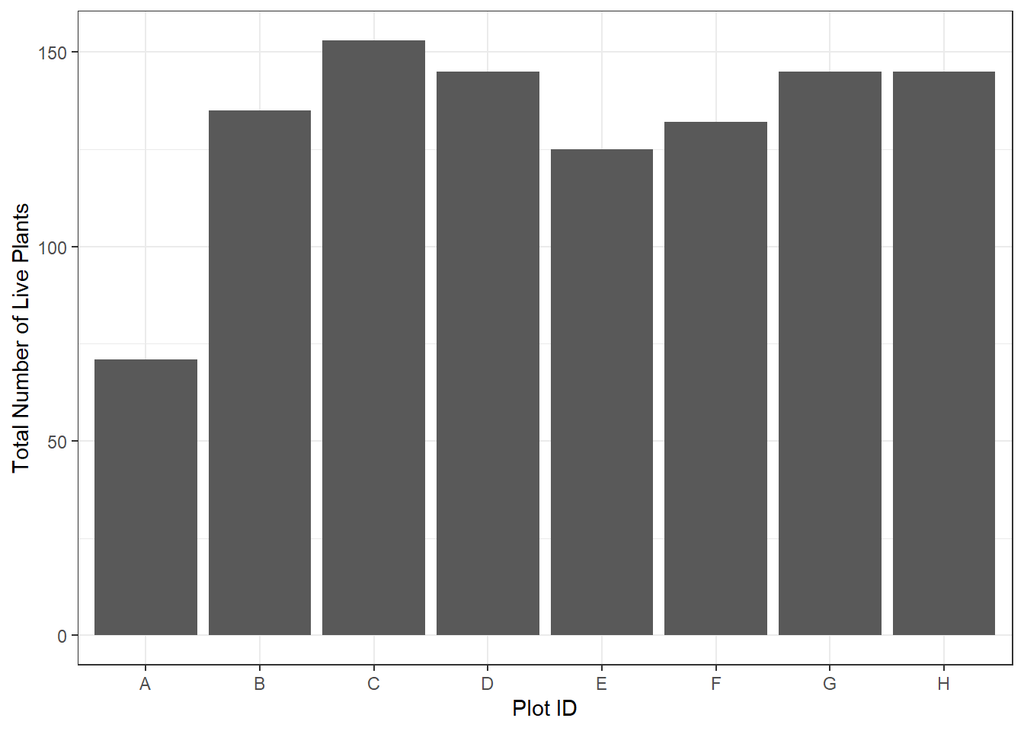

```r
# graphing mortality by plot
ggplot(mort_plot, aes(x = plot_id, y = mort_sum)) +
  geom_col() +
  theme_bw() +
  labs(x = "Plot ID",
       y = "Total Number of Live Plants")
```

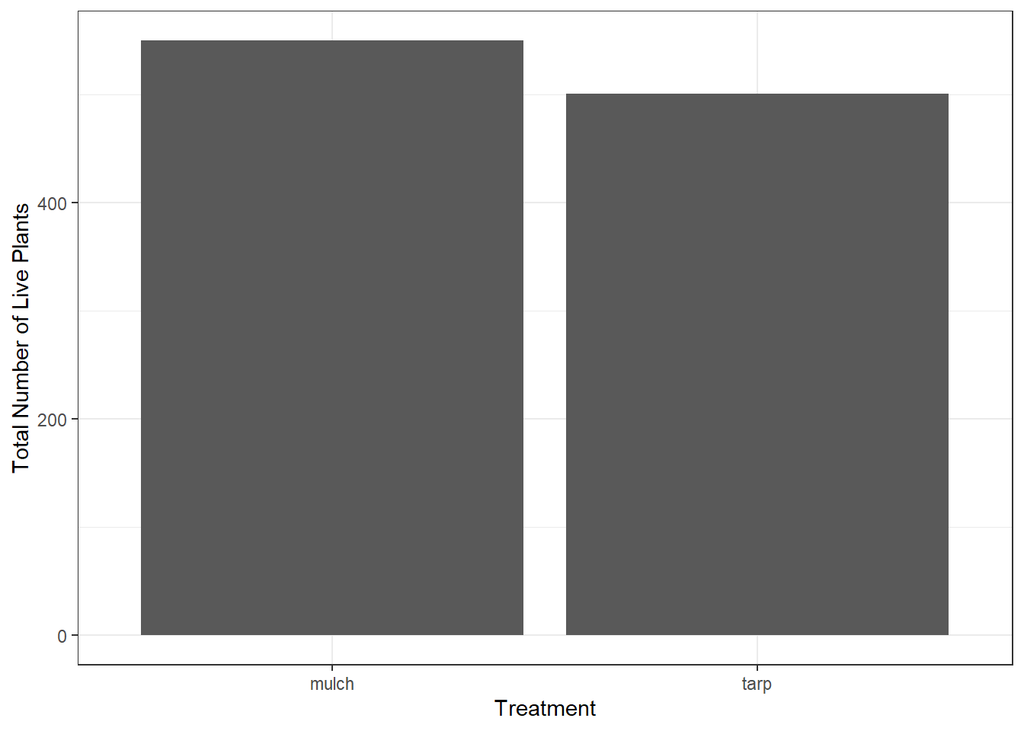

```r
# graphing mortality by treatment
ggplot(data = mort_treatment, aes(x = treatment, y = mort_sum)) +
  geom_col() +
  theme_bw() +
  labs(x = "Treatment",
       y = "Total Number of Live Plants")
```

## Continued analysis

The following code examines the differences in biomass and mortality for species based on region, province, treatment, and plot.

```r
#calculating % plants alive in each plot

#filtering for only tarp treatment to see the total number of plants (both A and D)
tarp_filt <- elings_data %>%
  filter(mortality_status == "D" | mortality_status == "A") %>%
  filter(treatment == "tarp") %>%
  count(mortality_status) %>%
            bind_rows(summarise(., across(where(is.numeric), sum),
                                   across(where(is.character), ~'Total'))) %>%
  rename(plant_count = n)


#filtering for only mulch treatment to see the total number of plants (both A and D)
mulch_filt <- elings_data %>%
  filter(mortality_status == "D" | mortality_status == "A") %>%
  filter(treatment == "mulch") %>%
  count(mortality_status) %>%
            bind_rows(summarise(., across(where(is.numeric), sum),
                                   across(where(is.character), ~'Total'))) %>%
  rename(plant_count = n)

stargazer(mulch_filt, summary = FALSE, type = "text")
```

```
##
## ==============================
##   mortality_status plant_count
## ------------------------------
## 1        A             550
## 2        D             106
## 3      Total           656
## ------------------------------
```

```r
#filtering for mortality data and grouping by plot
plot_filt <- elings_data %>%
  group_by(plot_id) %>%
  summarise(alive_pl = sum(mortality_status == "A"),
            dead_pl = sum(mortality_status == "D"),
            total = alive_pl + dead_pl,
            alive_prop = alive_pl / total,
            dead_prop = dead_pl / total,
            biomass = sum(biomass_kg_m2)) %>%
  mutate(treatment = case_when(plot_id == "A" ~ "Tarp", # adding a treatment column
                               plot_id == "B" ~ "Mulch",
                               plot_id == "C" ~ "Tarp",
                               plot_id == "D" ~ "Mulch",
                               plot_id == "E" ~ "Mulch",
                               plot_id == "F" ~ "Tarp",
                               plot_id == "G" ~ "Mulch",
                               plot_id == "H" ~ "Tarp"))

stargazer(plot_filt, summary = FALSE, type = "text")
```

```
##
## ======================================================================================
##   plot_id alive_pl dead_pl total    alive_prop         dead_prop     biomass treatment
## --------------------------------------------------------------------------------------
## 1    A       71      31     102  0.696078431372549 0.303921568627451 6.1453    Tarp
## 2    B      135      28     163  0.828220858895706 0.171779141104294 37.2512   Mulch
## 3    C      153      17     170         0.9               0.1        58.9236   Tarp
## 4    D      145      17     162  0.895061728395062 0.104938271604938 67.7381   Mulch
## 5    E      125      38     163  0.766871165644172 0.233128834355828 37.3939   Mulch
## 6    F      132      27     159  0.830188679245283 0.169811320754717 41.7185   Tarp
## 7    G      145      23     168  0.863095238095238 0.136904761904762 72.5257   Mulch
## 8    H      145      18     163  0.889570552147239 0.110429447852761 47.8082   Tarp
## --------------------------------------------------------------------------------------
```

```r
#making a pretty table to show mortality data
plot_filt %>%
  kable(caption = "Plot Mortality Status Data",
        col.names = c("Plot ID","# Alive Plants","# Dead Plants", "Total","Proportion of plants alive","Proportion of plants dead", "Biomass kg/m2", "Treatment"),
        format = "html",table.attr = "style = 'width:70%'") %>%
kable_styling(bootstrap_options = "striped")
```

Plot Mortality Status Data

| Plot ID | # Alive Plants | # Dead Plants | Total | Proportion of plants alive | Proportion of plants dead | Biomass kg/m2 | Treatment |
| --- | --- | --- | --- | --- | --- | --- | --- |
| A | 71 | 31 | 102 | 0.6960784 | 0.3039216 | 6.1453 | Tarp |
| B | 135 | 28 | 163 | 0.8282209 | 0.1717791 | 37.2512 | Mulch |
| C | 153 | 17 | 170 | 0.9000000 | 0.1000000 | 58.9236 | Tarp |
| D | 145 | 17 | 162 | 0.8950617 | 0.1049383 | 67.7381 | Mulch |
| E | 125 | 38 | 163 | 0.7668712 | 0.2331288 | 37.3939 | Mulch |
| F | 132 | 27 | 159 | 0.8301887 | 0.1698113 | 41.7185 | Tarp |
| G | 145 | 23 | 168 | 0.8630952 | 0.1369048 | 72.5257 | Mulch |
| H | 145 | 18 | 163 | 0.8895706 | 0.1104294 | 47.8082 | Tarp |

```r
# filtering to get a dataset with region info
region_filt <- elings_data %>%
  group_by(region) %>%
  summarise(alive_pl = sum(mortality_status == "A"),
            dead_pl = sum(mortality_status == "D"),
            total = alive_pl + dead_pl,
            alive_prop = alive_pl / total,
            dead_prop = dead_pl / total,
            biomass = sum(biomass_kg_m2))

#filtering to get a dataset with province info for STPU
province_stpu <- elings_data %>%
  filter(province_info == "SB" | province_info == "IRV" | province_info == "SD") %>%
  filter(species_id == "STPU") %>%
  group_by(province_info) %>%
  summarise(alive_pl = sum(mortality_status == "A"),
            dead_pl = sum(mortality_status == "D"),
            total = alive_pl + dead_pl,
            alive_prop = alive_pl / total,
            dead_prop = dead_pl / total,
            biomass = sum(biomass_kg_m2),
            biomass_per_pl = biomass / alive_pl)

#making a table to display STPU province information
province_stpu %>%
  kable(caption = "Stipa Pulchra Province Data",
        col.names = c("Province Info", "# Alive Plants", "# Dead Plants", "Total", "Proportion of plants alive", "Proportion of plants dead", "Biomass kg/m2", "Biomass kg/m2 per plant"),
        format = "html", table.attr = "style = 'width:80%;'") %>%
  kable_styling(bootstrap_options = "striped")
```

Stipa Pulchra Province Data

| Province Info | # Alive Plants | # Dead Plants | Total | Proportion of plants alive | Proportion of plants dead | Biomass kg/m2 | Biomass kg/m2 per plant |
| --- | --- | --- | --- | --- | --- | --- | --- |
| IRV | 17 | 0 | 17 | 1 | 0 | 10.5869 | 0.6227588 |
| SB | 21 | 0 | 21 | 1 | 0 | 10.7956 | 0.5140762 |
| SD | 18 | 0 | 18 | 1 | 0 | 16.2065 | 0.9003611 |

```r
stargazer(province_stpu, summary = FALSE, type = "text")
```

```
##
## =====================================================================================
##   province_info alive_pl dead_pl total alive_prop dead_prop biomass  biomass_per_pl
## -------------------------------------------------------------------------------------
## 1      IRV         17       0     17       1          0     10.5869 0.622758823529412
## 2      SB          21       0     21       1          0     10.7956 0.51407619047619
## 3      SD          18       0     18       1          0     16.2065 0.900361111111111
## -------------------------------------------------------------------------------------
```

```r
#filtering to get a dataset with province info for EPCA
province_epca <- elings_data %>%
  filter(province_info == "SB" | province_info == "IRV" | province_info == "SD") %>%
  filter(species_id == "EPCA") %>%
  group_by(province_info) %>%
  summarise(alive_pl = sum(mortality_status == "A"),
            dead_pl = sum(mortality_status == "D"),
            total = alive_pl + dead_pl,
            alive_prop = alive_pl / total,
            dead_prop = dead_pl / total,
            biomass = sum(biomass_kg_m2),
            biomass_per_pl = biomass / alive_pl)

#making a table to display EPCA province info
province_epca %>%
  kable(caption = "Epilobium Canum Province Data",
        col.names = c("Province Info", "# Alive Plants", "# Dead Plants", "Total","Proportion of plants alive", "Proportion of plants dead", "Biomass kg/m2", "Biomass kg/m2 per plant"),
        format = "html", table.attr = "style = 'width:80%;'") %>%
  kable_styling(bootstrap_options = c("hover", "condensed"))
```

Epilobium Canum Province Data

| Province Info | # Alive Plants | # Dead Plants | Total | Proportion of plants alive | Proportion of plants dead | Biomass kg/m2 | Biomass kg/m2 per plant |
| --- | --- | --- | --- | --- | --- | --- | --- |
| SB | 11 | 1 | 12 | 0.9166667 | 0.0833333 | 2.5196 | 0.2290545 |
| SD | 14 | 0 | 14 | 1.0000000 | 0.0000000 | 3.9916 | 0.2851143 |

```r
stargazer(province_epca, type = "text", summary = FALSE)
```

```
##
## =====================================================================================================
##   province_info alive_pl dead_pl total    alive_prop         dead_prop      biomass  biomass_per_pl
## -----------------------------------------------------------------------------------------------------
## 1      SB          11       1     12   0.916666666666667 0.0833333333333333 2.5196  0.229054545454545
## 2      SD          14       0     14           1                 0          3.9916  0.285114285714286
## -----------------------------------------------------------------------------------------------------
```

Now let’s plot the filtered data

[figure not shown]

```r
#creating new dataset to look at data by species
species_data <- elings_data %>%
  group_by(species_id) %>%
  summarise(alive_pl = sum(mortality_status == "A"),
            dead_pl = sum(mortality_status == "D"),
            total = alive_pl + dead_pl,
            alive_prop = alive_pl / total,
            dead_prop = dead_pl / total,
            biomass = sum(biomass_kg_m2),
            biomass_per_pl = biomass / alive_pl)

#plotting species data for avg biomass
ggplot(data = species_data, aes(x = species_id, y = biomass)) +
  geom_col() +
  theme_bw() +
  labs(x = "Species",
       y = "Average Biomass (kg/m2) per plant")
```

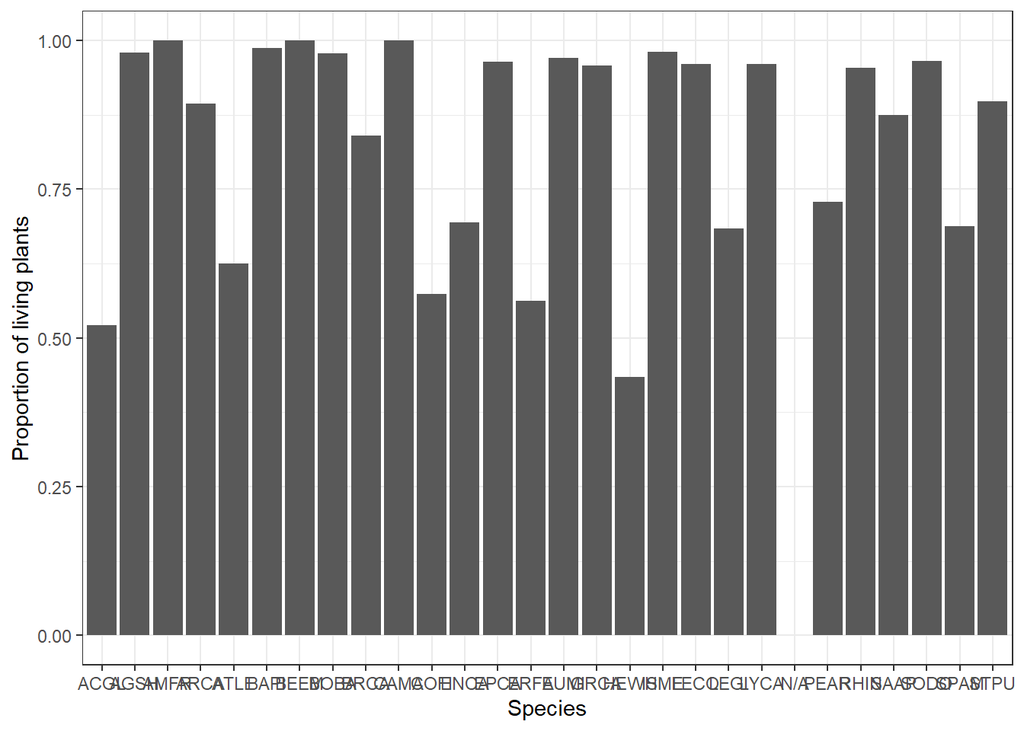

```r
#plotting % alive for each species
ggplot(data = species_data, aes(x = species_id, y = alive_prop)) +
  geom_col() +
  theme_bw() +
  labs(x = "Species",
       y = "Proportion of living plants")
```

```r
#table to display species data
stargazer(species_data, type = "text", summary = FALSE,
          report = "vc*",
          df = FALSE,
          header = FALSE,
          digits = 3,
          covariate.labels = c("Sample", "Species ID", "Living Plants", "Dead Plants", "Total Plants", "Proportion Alive", "Proportion Dead", "Total Biomass", "Average Biomass per Plant"))
```

```
##
## =====================================================================================================================================
## Sample Species ID Living Plants Dead Plants Total Plants Proportion Alive   Proportion Dead   Total Biomass Average Biomass per Plant
## -------------------------------------------------------------------------------------------------------------------------------------
## 1         ACGL         24           22           46      0.521739130434783 0.478260869565217     14.8851            0.6202125
## 2         AGSH         49            1           50            0.98               0.02            2.191        0.0447142857142857
## 3         AMFR         14            0           14              1                 0             4.6158              0.3297
## 4         ARCA         42            5           47      0.893617021276596 0.106382978723404     25.0379        0.596140476190476
## 5         ATLE         20           12           32            0.625             0.375           2.6838              0.13419
## 6         BAPI         77            1           78      0.987179487179487 0.0128205128205128    25.8967        0.336320779220779
## 7         BEEM         48            0           48              1                 0             0.4245            0.00884375
## 8         BOBA         46            1           47      0.978723404255319 0.0212765957446809    16.4328        0.357234782608696
## 9         BRCA         42            8           50            0.84               0.16           6.6225         0.157678571428571
## 10        CAMA         11            0           11              1                 0             4.2735              0.3885
## 11        COFI         27           20           47      0.574468085106383 0.425531914893617     2.4561        0.0909666666666667
```

[output cut: 18 more lines]

## Future plans

Future analysis will include:

- color = treatment to make graphs better
- analyzing average biomass per plant per plot
- average biomass per species per treatment
- compare san diego scrub species across treatments (bergaro, lycium, agave, amorpha, euphorbia) how are species that wouldn’t normally be found at Elings
- rates of growth in future surveys
- does decomposition correlate to plant growth in any way?

The analysis will (hopefully) answer these questions:

- Do tarped plots or mulched plots promote more growth?
- Which treatment has the lowest mortality rate?
- Which species performed the best (in terms of growth and survival) in each plot and each treatment? Is one treatment better for some plants, while the other treatment is better for other plants?
- Does origin impact plant mortality or growth?
- Which stpu location grew the most? Which stpu location had the best survival rates?